### **Data source**

Mortality data were downloaded from [the Public Health England Outcomes Framework website](https://fingertips.phe.org.uk/profile/mortality-profile/data). These data relate to *premature mortality* - deaths under age 75 for all causes combined, and to *preventable mortality* - where all or most deaths could potentially be prevented through public health interventions.

All rates are age-standardised and data have been smoothed over three years.

### 1) **Comparing premature mortality in London with other regions of the UK**

The plot below shows that compared to the overall rate for England (first bar), London’s premature mortality rate (fifth bar) is below average. The highest rates are in the North-East and North-West regions.

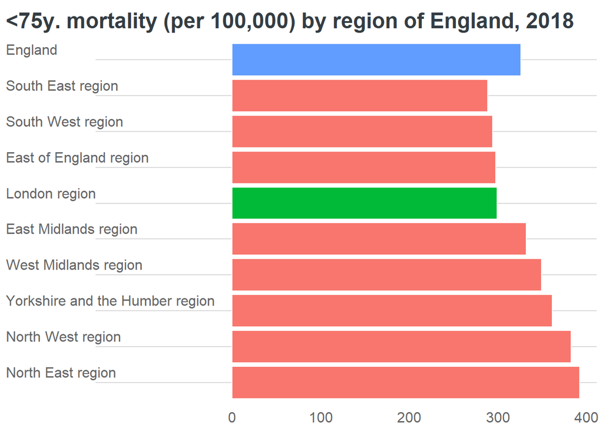

### 2) **Examining premature mortality trend in London over the last two decades**

The plot below shows that premature mortality in London has decreased steadily over the last two decades.

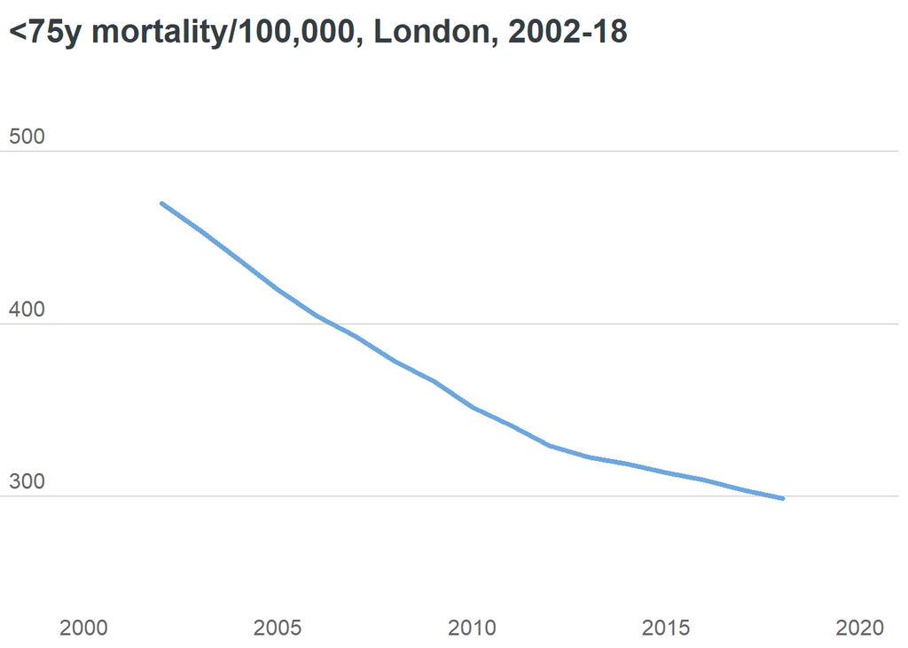

### 3) **Comparing the time-trend in premature mortality for London with other regions in England**

The plot below shows London (green line) has had a greater decrease in premature mortality than the other English regions.

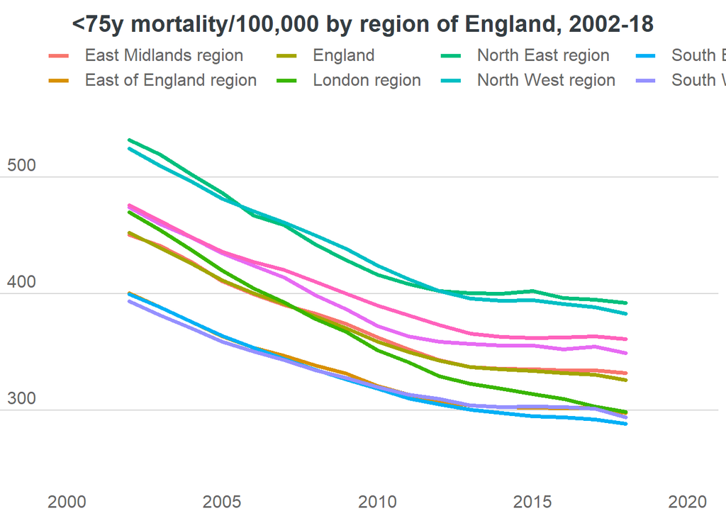

### 4) **Variation in premature mortality by London borough in 2018**

The borough of Barking and Dagenham has the highest premature mortality rate at over 400 per 100,000, almost twice the lowest borough value (City of London).

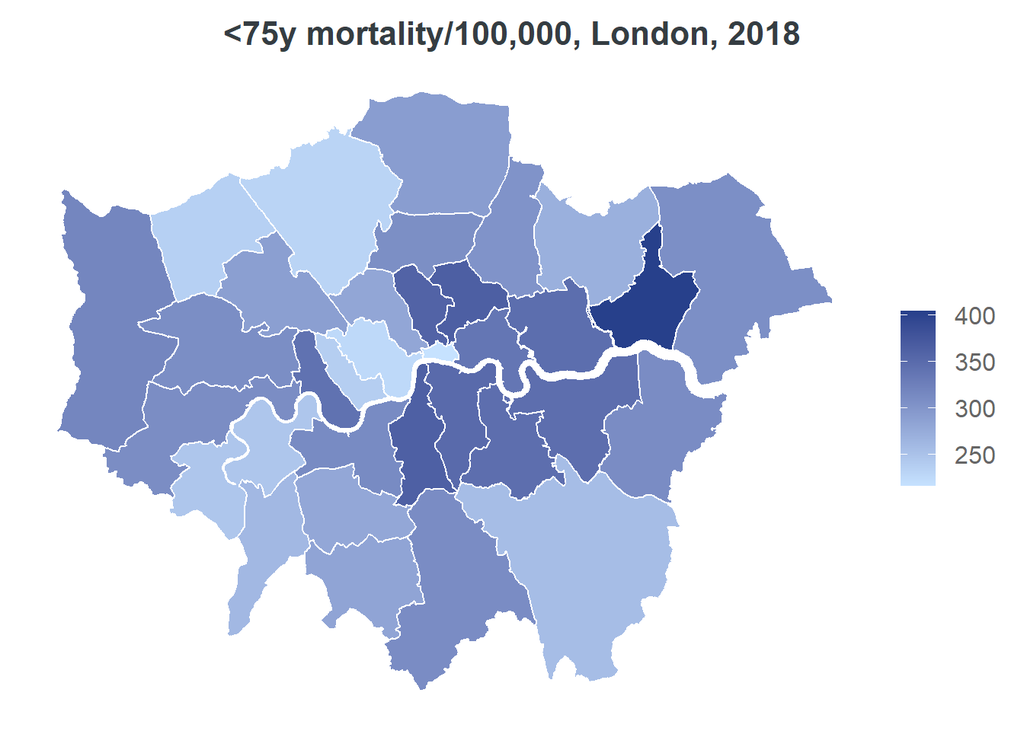

### 5) **Variation in preventable mortality by borough in 2018**

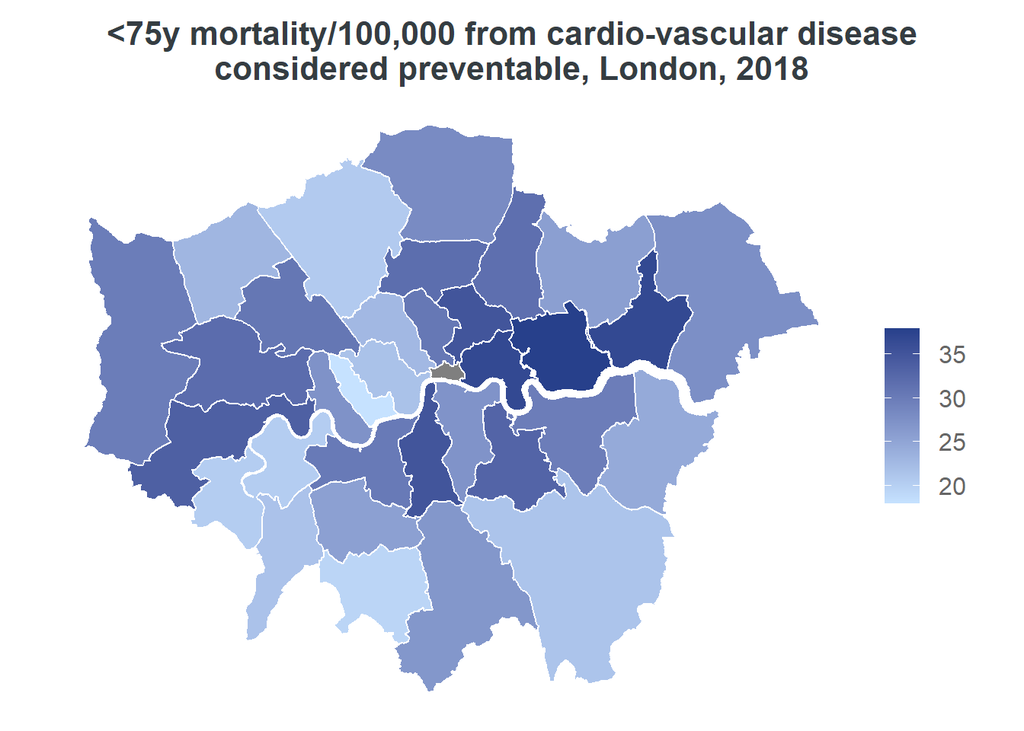

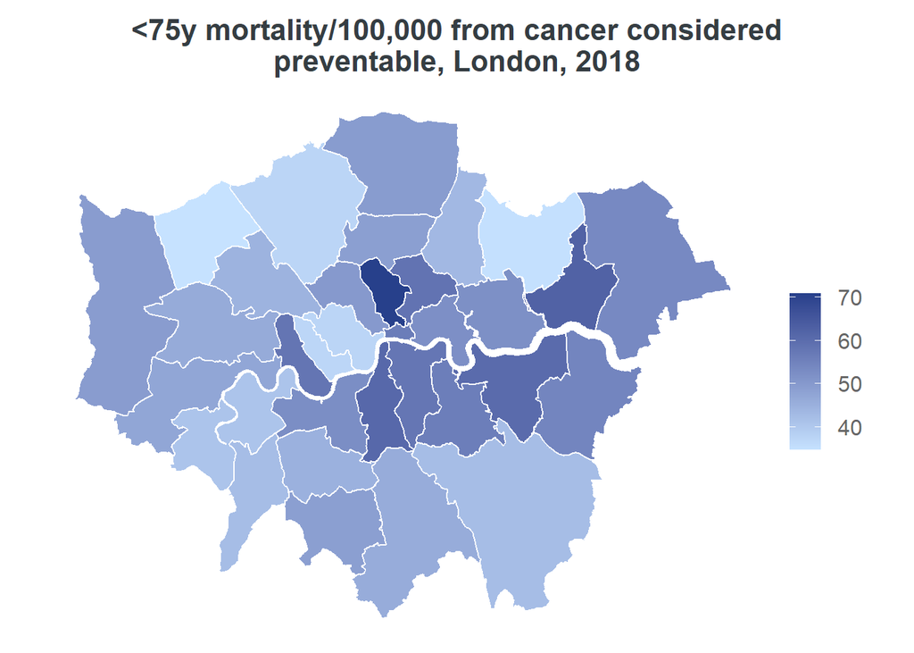

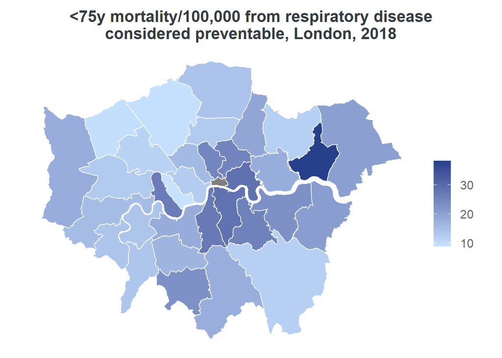

$~$